# Exploring Stackloss dataset creating a linear regression model

Diego Gaona

December 30, 2017

# Application

This is presentation pitch for the final project of Developing Data Products.

[Developing Data Products Project](https://caturra.shinyapps.io/ddp_shinyproject/)

The project is a proof of concept and pretend to be a simple Shiny Application to explore the Stackloss dataset, also there is an implmentation of a linear model and a plot that display the variables and the relationship among them.

# Dataset

The dataset used is `stackloss` (Brownlee’s Stack Loss Plant Data), which is the operational data of a plant for the oxidation of ammonia to nitric acid.

stackloss is a data frame with 21 observations on 4 variables.

- [,1] Air Flow Flow of cooling air
- [,2] Water Temp Cooling Water Inlet Temperature
- [,3] Acid Conc. Concentration of acid [per 1000, minus 500]
- [,4] stack.loss Stack loss

The app offers to the user the ability to plot the variables and apply a color coding based on a indepent variable.

There’s a feature to subset data (toogle points) and a summary of the linear model.

# Application plot

By default, the application will show the variables `stack.loss` and `Air.Flow`.

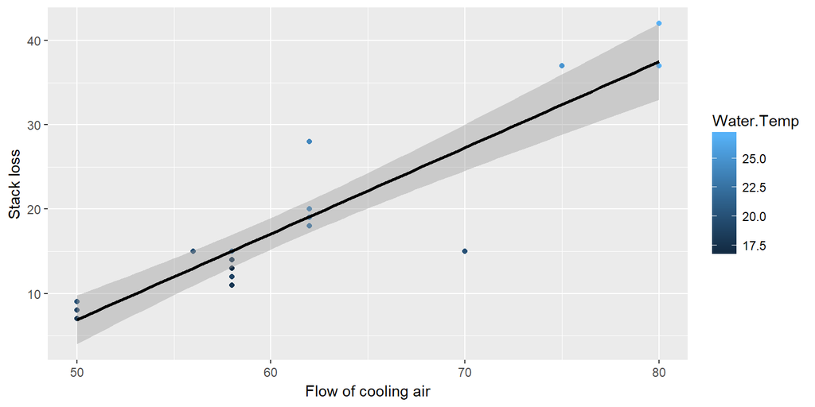

```r
  ggplot(dataset) + aes(x = Air.Flow, y = stack.loss, color = Water.Temp) + geom_point() +
    xlab("Flow of cooling air") + ylab("Stack loss") +
    geom_smooth(method = lm, fullrange = TRUE, color = "black")
```

# Linear Model

In the summary panel, will be appear the linear model for the `predictor ~ outcome` selected.

```r
  # Calculate linear model
  summary(lm(data = dataset, stack.loss ~ Air.Flow))
```

```
##
## Call:
## lm(formula = stack.loss ~ Air.Flow, data = dataset)
##
## Residuals:
##      Min       1Q   Median       3Q      Max
## -12.2896  -1.1272  -0.0459   1.1166   8.8728
##
## Coefficients:
##              Estimate Std. Error t value Pr(>|t|)
## (Intercept) -44.13202    6.10586  -7.228 7.31e-07 ***
## Air.Flow      1.02031    0.09995  10.208 3.77e-09 ***
## ---
## Signif. codes:  0 '***' 0.001 '**' 0.01 '*' 0.05 '.' 0.1 ' ' 1
##
## Residual standard error: 4.098 on 19 degrees of freedom
## Multiple R-squared:  0.8458, Adjusted R-squared:  0.8377
## F-statistic: 104.2 on 1 and 19 DF,  p-value: 3.774e-09
```